# Week 8 Exercises: GLM, LMM, and GLMM

Sabrina McNew

2023-10-12

```r
# Packages used (install as needed)
library(ggplot2)
library(ggthemr)
library(lmerTest) # for extracting p vals from mixed models
library(lme4) # mixed models
library(dplyr)
```

```r
# datasets used
nestlings <- read.csv("../datasets/nestlings.csv")
swallows <- read.csv("../datasets/swallows.csv")

# optional set theme
ggthemr(palette = "flat dark", layout = "clean", text_size = 18)
```

###Question 1:  
In the swallows dataset, each row is a breeding female tree swallow and the columns tell you her brightness, which treatment she was in, her brood size, and her breeding success. There are two ways to consider breeding success: either as a binary “did she fledge any young or not?” encoded in the “success” column, or by considering the number of nestlings that lived and died per female (“nestlings_lived” and “nestlings_died” columns).

1a. Create a plot of the proportion of successful breeders in the predation group and in the control group.

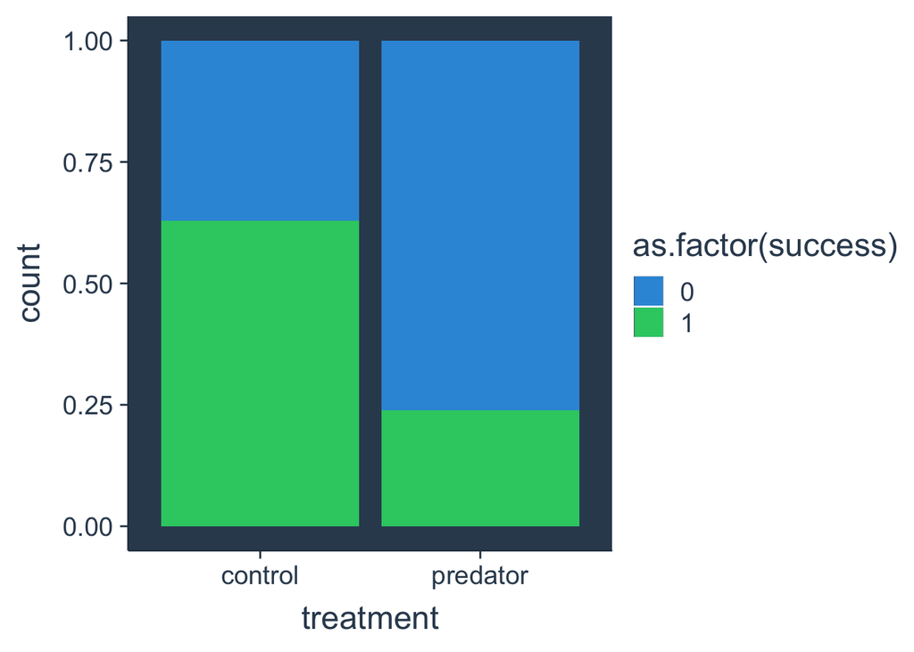

```r
swallows %>%
  ggplot(aes(x = treatment, fill = as.factor(success))) +
  geom_bar(position = "fill")
```

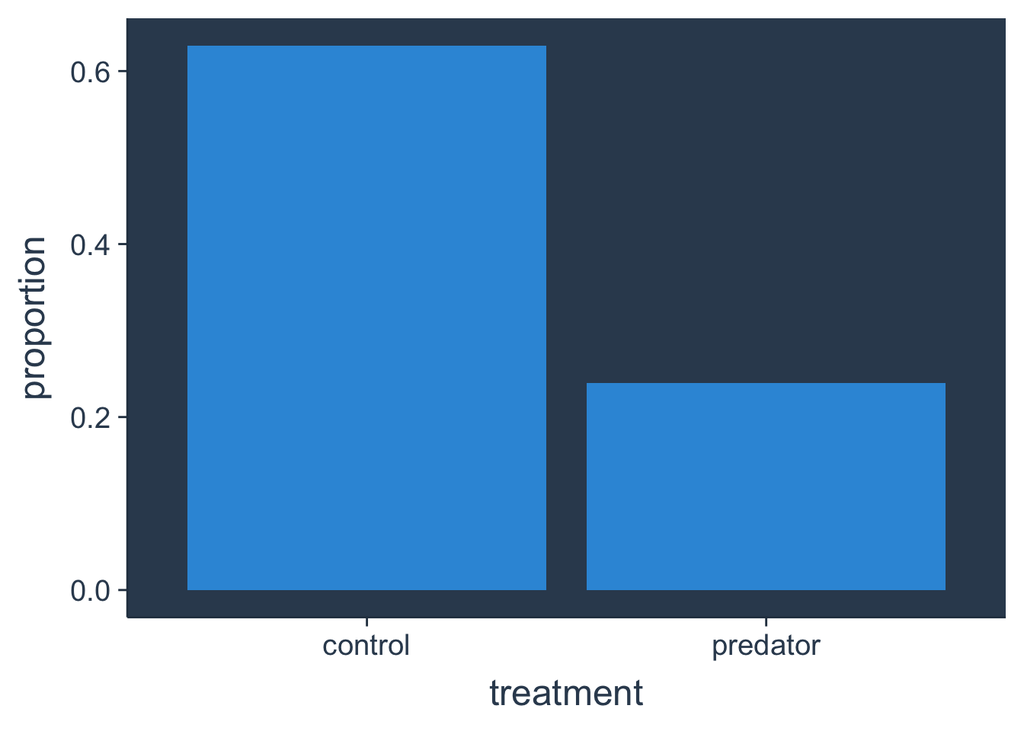

```r
# another option if we just want to visualize success:
swallows %>%
group_by(treatment) %>%
summarize(proportion = mean(success)) %>%
  ggplot(aes(x= treatment, y = proportion)) +
  geom_col()
```

1b. Create a plot of the overall percentage of nestlings that fledged in the predator and control groups.

```r
head(swallows)
```

```
##   brightness success treatment brood_size nestlings_died nestlings_lived
## 1   4.810745       0  predator          4              4               0
## 2   4.624764       1   control          6              1               5
## 3   4.621162       1   control          3              2               1
## 4   4.840272       1   control          5              1               4
## 5   4.407832       0  predator          6              6               0
## 6   4.426604       0  predator          2              2               0
```

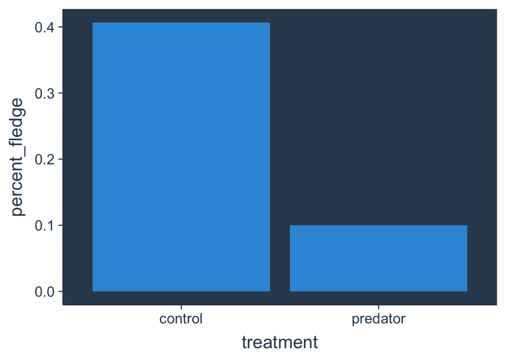

```r
#I'm old so I'm going to use aggregate in base r. summarize in dplyr will also work
bird_sums <- aggregate(cbind(nestlings_lived, brood_size) ~ treatment, data = swallows, FUN = sum)

bird_sums %>%
  mutate(percent_fledge = nestlings_lived/brood_size) %>%
  ggplot(aes(x = treatment, y = percent_fledge)) +
  geom_col()
```

1c. Use a generalized linear model (aka logistic regression) to test whether breeding success differed between predator and control groups using “success” as a response variable.

```r
glm(success ~ treatment, data = swallows, family = "binomial") %>% summary()
```

```
##
## Call:
## glm(formula = success ~ treatment, family = "binomial", data = swallows)
##
## Deviance Residuals:
##     Min       1Q   Median       3Q      Max
## -1.4094  -0.7393  -0.7393   0.9619   1.6916
##
## Coefficients:
##                   Estimate Std. Error z value Pr(>|z|)
## (Intercept)         0.5306     0.2818   1.883 0.059702 .
## treatmentpredator  -1.6881     0.4460  -3.785 0.000154 ***
## ---
## Signif. codes:  0 '***' 0.001 '**' 0.01 '*' 0.05 '.' 0.1 ' ' 1
##
## (Dispersion parameter for binomial family taken to be 1)
##
##     Null deviance: 137.63  on 99  degrees of freedom
## Residual deviance: 121.80  on 98  degrees of freedom
## AIC: 125.8
##
## Number of Fisher Scoring iterations: 4
```

Sabrina’s note: See that this will run, and it will give you the “right” answer. It’s pretty easy to draw a line through things and it is interpreting that there’s more “1s” in the control group than in the treatment group. R is not going to tell you that you’re using the “wrong” model, that’s up to you. But, it is reassuring to know that different models will come to the same conclusion.

1d. Use a generalized linear model (aka logistic regression) to test whether the proportion of nestlings that fledged from each nest differed between treatments. How do you interpret the output?

```r
glm(cbind(nestlings_lived, nestlings_died) ~ treatment, data  = swallows,
    family = "binomial") %>% summary()
```

```
##
## Call:
## glm(formula = cbind(nestlings_lived, nestlings_died) ~ treatment,
##     family = "binomial", data = swallows)
##
## Deviance Residuals:
##     Min       1Q   Median       3Q      Max
## -2.8902  -1.2355  -0.7221   1.3545   3.6915
##
## Coefficients:
##                   Estimate Std. Error z value Pr(>|z|)
## (Intercept)        -0.3776     0.1244  -3.036   0.0024 **
## treatmentpredator  -1.8197     0.2525  -7.206 5.77e-13 ***
## ---
## Signif. codes:  0 '***' 0.001 '**' 0.01 '*' 0.05 '.' 0.1 ' ' 1
##
## (Dispersion parameter for binomial family taken to be 1)
##
##     Null deviance: 378.92  on 97  degrees of freedom
## Residual deviance: 314.63  on 96  degrees of freedom
## AIC: 379.78
##
## Number of Fisher Scoring iterations: 4
```

1e. Use a generalized linear model to test whether the total number of offspring that females succesfully produced differed between treatment and control groups. What glm family should you use?

```r
glm(nestlings_lived ~ treatment, data = swallows, family = "quasipoisson") %>% summary()
```

```
##
## Call:
## glm(formula = nestlings_lived ~ treatment, family = "quasipoisson",
##     data = swallows)
##
## Deviance Residuals:
##     Min       1Q   Median       3Q      Max
## -2.0092  -1.0000  -1.0000   0.6438   3.1041
##
## Coefficients:
##                   Estimate Std. Error t value Pr(>|t|)
## (Intercept)         0.7024     0.1414   4.969 2.86e-06 ***
## treatmentpredator  -1.3955     0.3386  -4.121 7.89e-05 ***
## ---
## Signif. codes:  0 '***' 0.001 '**' 0.01 '*' 0.05 '.' 0.1 ' ' 1
##
## (Dispersion parameter for quasipoisson family taken to be 2.177871)
##
##     Null deviance: 256.11  on 99  degrees of freedom
## Residual deviance: 208.17  on 98  degrees of freedom
## AIC: NA
##
## Number of Fisher Scoring iterations: 6
```

```r
mean(swallows$nestlings_lived)
```

```
## [1] 1.32
```

```r
var(swallows$nestlings_lived)
```

```
## [1] 3.411717
```

Sabrina’s notes: Number of fledglings per nest is something that might feel pretty poisson-y. Again, beause I know it’s never poisson, I’m going to use a relative, in this case “quasipoisson.” In this case, when we look at the mean vs. var of nestlings_lived, it’s not *that* over-dispersed. But, there’s no real harm here in using an alternative.

One other thing to maybe note: in cases like this we may run into what’s called “zero inflated data.” That’s when we have more zeros than we’d expect, for example, because some biological process is generating complete nest failures (like predation). Then, a separate process generates variation fledging success among those nests pass the baseline of “not failing.” There are some other packages that are useful for modeling zero inflated data and other flavors of not-poisson. But save that for another day…

1f: Considering your approaches in 1c - 1e: what is the “best” way to answer the question: “Did predation affect breeding success of swallows?” Why?

?????? Up to you! They arguably measure different things:  
1) Did a female bird have any reproductive success or not (success ~ treatment)  
2) What proportion of nestlings fledged in each treatment? (cbind(lived,died) ~ treatment)  
3) Did total fitness depend on treatment? (lived ~ treatment)

### Question 2:

You also have data from each nestling in this experiment in the “nestlings” dataframe, which includes measurements at 12 days of age of their mass and their wing length. You want to determine whether being in a “predation” or “control” treatment had an effect on individual nestling mass. So you set out to model the effect of treatment on nestling mass using lm(). “HOLD UP” your advisor says, that’s pseudoreplication, because each nestling is not independent. “What you need to do is take the average mass for each nest and then model average mass based on treatment” “But,” you say, “that will sacrifice a lot of power! Maybe there’s another way…”

2a. Make a plot of mean mass for the predator and control treatments

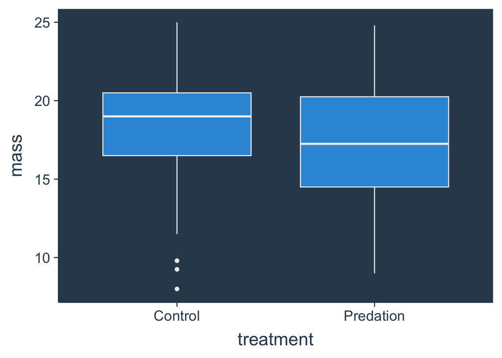

```r
nestlings |> ggplot(aes(x = treatment, y = mass)) + geom_boxplot()
```

2b. Make a lm that tests the effect of treatment on nestling size. How do you interpret the coefficients and p vals?

```r
lm(mass ~ treatment, data = nestlings) |> summary()
```

```
##
## Call:
## lm(formula = mass ~ treatment, data = nestlings)
##
## Residuals:
##      Min       1Q   Median       3Q      Max
## -10.5455  -2.4509   0.3018   2.4545   7.3491
##
## Coefficients:
##                    Estimate Std. Error t value Pr(>|t|)
## (Intercept)         18.5455     0.2535   73.15   <2e-16 ***
## treatmentPredation  -1.0945     0.4130   -2.65   0.0085 **
## ---
## Signif. codes:  0 '***' 0.001 '**' 0.01 '*' 0.05 '.' 0.1 ' ' 1
##
## Residual standard error: 3.373 on 282 degrees of freedom
## Multiple R-squared:  0.0243, Adjusted R-squared:  0.02084
## F-statistic: 7.023 on 1 and 282 DF,  p-value: 0.008503
```

The bare-bones lm is pretty confident that nestlings in the Predation treatment were smaller than the Controls (P = 0.0085). Specifically, nestlings in the control group weighed ~ 18g (on day 12) while nestlings in the predation group weighed ~ 17g (18.5 - 1.09) at the same age.

2c. Make a lmm that tests the effects of treatment on nestling size, properly accounting for the interdependence of nestlings within the same nest. (hint: lmer()). Compare and contrast the results of your lm and lmm. How do the coefficients and p values differ?

```r
lmer(mass ~ treatment + (1|nest), data = nestlings) |> summary()
```

```
## Linear mixed model fit by REML. t-tests use Satterthwaite's method [
## lmerModLmerTest]
## Formula: mass ~ treatment + (1 | nest)
##    Data: nestlings
##
## REML criterion at convergence: 1444.3
##
## Scaled residuals:
##     Min      1Q  Median      3Q     Max
## -3.9368 -0.5491  0.0850  0.5796  2.4106
##
## Random effects:
##  Groups   Name        Variance Std.Dev.
##  nest     (Intercept) 5.090    2.256
##  Residual             7.223    2.688
## Number of obs: 284, groups:  nest, 53
##
## Fixed effects:
##                    Estimate Std. Error       df t value Pr(>|t|)
## (Intercept)         18.3223     0.4205  57.8566  43.570   <2e-16 ***
## treatmentPredation  -0.5051     0.5785 133.6232  -0.873    0.384
## ---
## Signif. codes:  0 '***' 0.001 '**' 0.01 '*' 0.05 '.' 0.1 ' ' 1
##
## Correlation of Fixed Effects:
##             (Intr)
## trtmntPrdtn -0.534
```

### Semi-important note I didn’t say in class:

It is very hard to calculate p values for LMMs because it’s hard to decide what the dfs are. Our rule of thumb is that dfs = N - number of estimated parameters. But what is N for a mixed model? It is not the number of nestlings (because of pseudoreplication), and it’s not exactly number of nests either (because we do have more information in our data set). It’s somewhere in the middle.

In order to extract P values, you have to make a decision about these dfs, and lme4 won’t do it on its own, because it does require some assumptions and is somewhat subjective. What lmerTest does is chooses a way to get a P value (the Satterthwaite method) and it runs it. But the writers of lmer4 didn’t want you sail by that point and they wanted you to realize it’s not trivial. In practice, using lmerTest is fairly common, and if you were using another stats program (SPSS etc.) in the fine print you’d read that they’re also using an “approximation” of some sort to get to the p vals for LMM.

###Question 3:  
Test for effects of treatment on individual nestling fledging success 3a: Make a plot showing the differences in percent fledging success for nestlings in the control vs. predator treatment

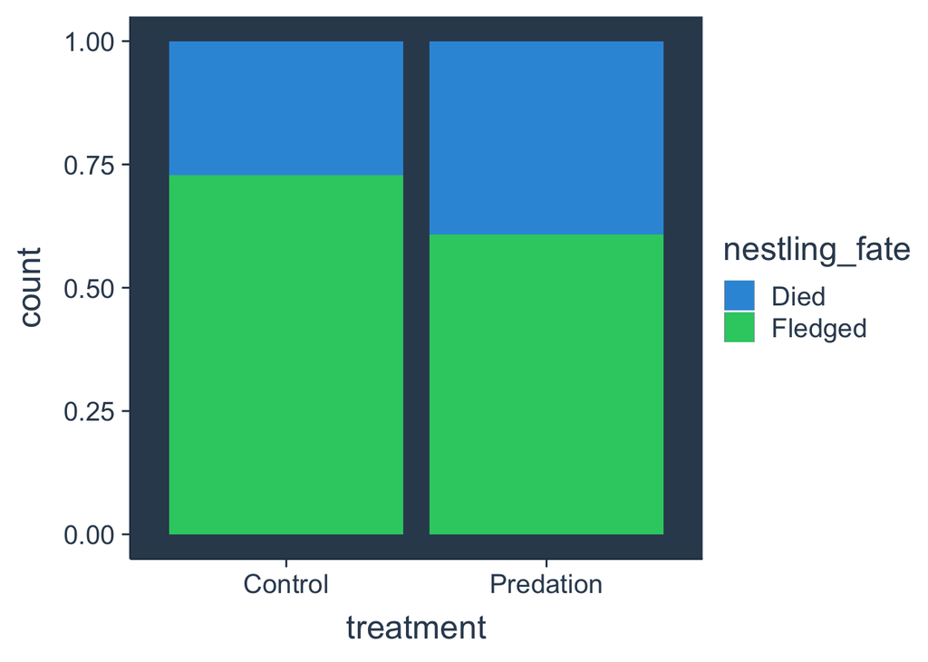

```r
nestlings %>% ggplot(aes(x = treatment, fill = nestling_fate)) + geom_bar(position = "fill")
```

3b: Use a normal lm to model the effects of treatment on fledging success (yes this isn’t the best approach). You’ll first want to create a new vector that codes nestling fate as a numeric value. How do you interpret these coefficients? Do they make sense?

```r
# note this way of adding a column isn't super readable but it works just fine.
# Another way to do it could be mutate(fledge_numeric = case_when(nestling_fate == "Fledged" ~ 1))
nestlings |>
  mutate (fledge_numeric = as.numeric(as.factor(nestling_fate))) %>%
  lm(fledge_numeric ~ treatment, data = .) %>%
  summary()
```

```
##
## Call:
## lm(formula = fledge_numeric ~ treatment, data = .)
##
## Residuals:
##     Min      1Q  Median      3Q     Max
## -0.7288 -0.6075  0.2712  0.2712  0.3925
##
## Coefficients:
##                    Estimate Std. Error t value Pr(>|t|)
## (Intercept)         1.72881    0.03481  49.658   <2e-16 ***
## treatmentPredation -0.12134    0.05672  -2.139   0.0333 *
## ---
## Signif. codes:  0 '***' 0.001 '**' 0.01 '*' 0.05 '.' 0.1 ' ' 1
##
## Residual standard error: 0.4632 on 282 degrees of freedom
## Multiple R-squared:  0.01597,    Adjusted R-squared:  0.01248
## F-statistic: 4.577 on 1 and 282 DF,  p-value: 0.03327
```

```r
# another note: because I'm moving quickly and not interested in saving
# a bunch of new objects to my environment I'm just going to pipe these things together.
# writing it this way will not preserve the new column, but that's ok with me.
```

## Super annoying and concerning error:

I’ve been trying to force myself to use the native pipe |> instead of the tidyverse pipe %>% recently because it seems like the new cool thing. However, I just found an example of where the |> pipe throws an unexpected error:

```r
# New pipe
nestlings |>
  mutate (fledge_numeric = as.numeric(as.factor(nestling_fate))) |>
  lm(fledge_numeric ~ treatment, data = _) # destination indicated by _

# Old pipe
nestlings |>
  mutate (fledge_numeric = as.numeric(as.factor(nestling_fate))) %>%
  lm(fledge_numeric ~ treatment, data = .) # destination indicated by .
```

Thanks to google I realized that if you want to set a destination for your piped object in old piping you use “.” and in new piping you use “_“. So that’s super annoying to me but now we know. It also appears that %>% can do a few things that |> cannot. Read more here: https://www.tidyverse.org/blog/2023/04/base-vs-magrittr-pipe/ It is generally good practice to use Base R functions when you can, because dependencies make things more complicated. However, ymmv with pipes- do what makes sense for your workflow.

3c: Use a generalized linear model aka logistic regression (glm(family = “binomial)) to model the effect of treatment on nestling fledging success. How do you interpret the coefficients?

Tip: R will not allow a character vector as a response in a logistic regression. however, it will take a 0 or 1 number, and it will take a vector encoded as a two-level factor

### going back to my old pipe

```r
glm(as.factor(nestling_fate) ~ treatment, data = nestlings, family = "binomial") %>%
  summary
```

```
##
## Call:
## glm(formula = as.factor(nestling_fate) ~ treatment, family = "binomial",
##     data = nestlings)
##
## Deviance Residuals:
##     Min       1Q   Median       3Q      Max
## -1.6155  -1.3676   0.7954   0.7954   0.9984
##
## Coefficients:
##                    Estimate Std. Error z value Pr(>|z|)
## (Intercept)          0.9886     0.1691   5.847    5e-09 ***
## treatmentPredation  -0.5519     0.2603  -2.120    0.034 *
## ---
## Signif. codes:  0 '***' 0.001 '**' 0.01 '*' 0.05 '.' 0.1 ' ' 1
##
## (Dispersion parameter for binomial family taken to be 1)
##
##     Null deviance: 354.72  on 283  degrees of freedom
## Residual deviance: 350.24  on 282  degrees of freedom
## AIC: 354.24
##
## Number of Fisher Scoring iterations: 4
```

The p value here (0.034) tells us that the probability than an individual nestling fledges is smaller in the predation group.

3d: Use a generalized linear mixed effects model to model the effect of treatment on nestling fledging success, accounting for the interdependence of nestlings. Interpret these results. Compare the results of the lm, glm, and glmm.

```r
glmer(as.factor(nestling_fate) ~ treatment + (1|nest), data = nestlings, family = "binomial") %>%
  summary()
```

```
## Generalized linear mixed model fit by maximum likelihood (Laplace
##   Approximation) [glmerMod]
##  Family: binomial  ( logit )
## Formula: as.factor(nestling_fate) ~ treatment + (1 | nest)
##    Data: nestlings
##
##      AIC      BIC   logLik deviance df.resid
##    291.4    302.4   -142.7    285.4      281
##
## Scaled residuals:
##     Min      1Q  Median      3Q     Max
## -2.8149 -0.3475  0.2125  0.4325  1.7673
##
## Random effects:
##  Groups Name        Variance Std.Dev.
##  nest   (Intercept) 6.256    2.501
## Number of obs: 284, groups:  nest, 53
##
## Fixed effects:
##                    Estimate Std. Error z value Pr(>|z|)
## (Intercept)          2.0165     0.5448   3.701 0.000215 ***
## treatmentPredation  -1.4338     0.6359  -2.255 0.024151 *
## ---
## Signif. codes:  0 '***' 0.001 '**' 0.01 '*' 0.05 '.' 0.1 ' ' 1
##
## Correlation of Fixed Effects:
##             (Intr)
## trtmntPrdtn -0.560
```

### Question 4:

The swallow nestlings were studied at 5 different sites, which varied in temperature, proximity to food sources, and overall quality. Site therefore may be an important random effect to consider in our analysis.

4a: Inspect nestlings$site. How many sites are there? How many nests were in each site? Make a plot of average nestling mass at each site. How does it vary?

Sabrina’s note: sorry, should have said “how many nestlings at each site.”

```r
table(nestlings$site) # five sites, most nestlings at unit 4
```

```
##
## unit_1 unit_2 unit_3 unit_4 unit_5
##     11     70     35    104     64
```

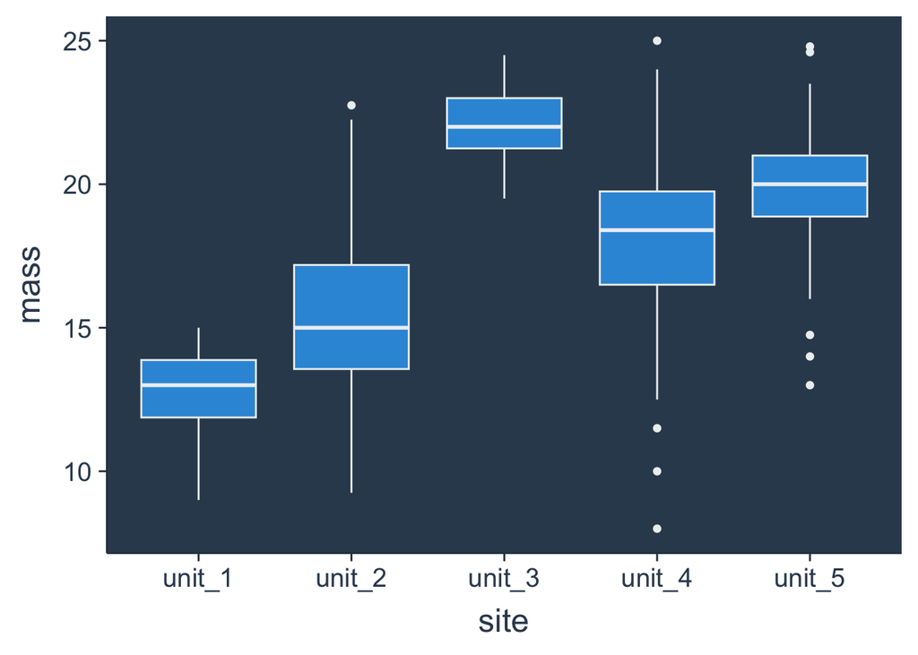

```r
nestlings %>%
  ggplot(aes(x = site, y = mass)) + geom_boxplot()
```

Interesting, nestling mass seems to vary quite a bit among sites 4b: Create a plot of the relationship between wing length and mass, coloring points by site. Add a simple regression line for the points of each site on top of your graph.

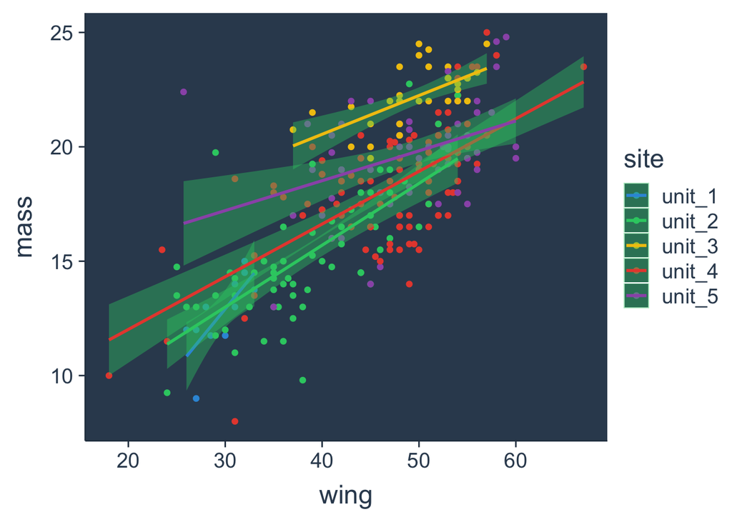

```r
nestlings %>%
  ggplot(aes(x = wing, y = mass, color = site)) +
  geom_point() +
  geom_smooth(method = "lm")
```

4c: Model the relationship between wing length and mass using a simple lm

```r
lm(mass ~ wing, data = nestlings) %>% summary() # super significant
```

```
##
## Call:
## lm(formula = mass ~ wing, data = nestlings)
##
## Residuals:
##     Min      1Q  Median      3Q     Max
## -6.2799 -1.5998 -0.1852  1.5578  9.8811
##
## Coefficients:
##             Estimate Std. Error t value Pr(>|t|)
## (Intercept)  5.07845    0.73164   6.941 2.71e-11 ***
## wing         0.28951    0.01592  18.183  < 2e-16 ***
## ---
## Signif. codes:  0 '***' 0.001 '**' 0.01 '*' 0.05 '.' 0.1 ' ' 1
##
## Residual standard error: 2.31 on 280 degrees of freedom
##   (2 observations deleted due to missingness)
## Multiple R-squared:  0.5415, Adjusted R-squared:  0.5398
## F-statistic: 330.6 on 1 and 280 DF,  p-value: < 2.2e-16
```

4d: Model the relationship between wing length and mass using the random effect of site.

```r
lmer(mass ~ wing + (1|site), data = nestlings) %>% summary
```

```
## Linear mixed model fit by REML. t-tests use Satterthwaite's method [
## lmerModLmerTest]
## Formula: mass ~ wing + (1 | site)
##    Data: nestlings
##
## REML criterion at convergence: 1200.5
##
## Scaled residuals:
##     Min      1Q  Median      3Q     Max
## -3.4263 -0.6614 -0.0244  0.5713  4.0226
##
## Random effects:
##  Groups   Name        Variance Std.Dev.
##  site     (Intercept) 3.739    1.934
##  Residual             3.826    1.956
## Number of obs: 282, groups:  site, 5
##
## Fixed effects:
##              Estimate Std. Error        df t value Pr(>|t|)
## (Intercept)   8.19989    1.12740  10.15525   7.273 2.47e-05 ***
## wing          0.22102    0.01642 279.51126  13.462  < 2e-16 ***
## ---
## Signif. codes:  0 '***' 0.001 '**' 0.01 '*' 0.05 '.' 0.1 ' ' 1
##
## Correlation of Fixed Effects:
##      (Intr)
## wing -0.627
```

Site does explain some variation in mass, but wing still explains a lot.

4e: What other random effects should you consider? Experiment with adding the random effect of nest. How should you add it? For a nice explanation of nested vs. crossed random effects read here: https://stats.stackexchange.com/questions/228800/crossed-vs-nested-random-effects-how-do-they-differ-and-how-are-they-specified

```r
mod1 <- lmer(mass ~ wing+ (1|year) + (1|site/nest), data = nestlings)
summary(mod1)
```

```
## Linear mixed model fit by REML. t-tests use Satterthwaite's method [
## lmerModLmerTest]
## Formula: mass ~ wing + (1 | year) + (1 | site/nest)
##    Data: nestlings
##
## REML criterion at convergence: 1170.9
##
## Scaled residuals:
##     Min      1Q  Median      3Q     Max
## -3.7155 -0.5888  0.0222  0.5695  3.9586
##
## Random effects:
##  Groups    Name        Variance Std.Dev.
##  nest:site (Intercept) 0.7117   0.8436
##  site      (Intercept) 2.7728   1.6652
##  year      (Intercept) 1.4589   1.2078
##  Residual              2.9694   1.7232
## Number of obs: 282, groups:  nest:site, 53; site, 5; year, 2
##
## Fixed effects:
##              Estimate Std. Error        df t value Pr(>|t|)
## (Intercept)   7.21583    1.32675   4.68348   5.439  0.00348 **
## wing          0.24501    0.01541 265.89021  15.894  < 2e-16 ***
## ---
## Signif. codes:  0 '***' 0.001 '**' 0.01 '*' 0.05 '.' 0.1 ' ' 1
##
## Correlation of Fixed Effects:
##      (Intr)
## wing -0.500
```

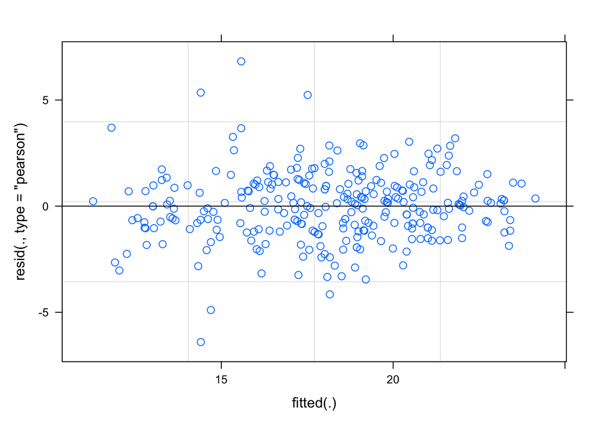

```r
plot(mod1) #Plot of residuals looks basically fine
```

```r
# See if a random slope will work. I won't do it for year, bc only two years.
# By putting "wing" in front of our random effects, we are asking R to say not only
# could the intercept (i.e. average mass) differ among sites and/or nests
# But the relationship betwene wing and mass (i.e. the slope) may also
# vary among sites and nests.
mod2 <- lmer(mass ~ wing+ (1|year) + (wing|site/nest), data = nestlings)
```

```
## Warning in checkConv(attr(opt, "derivs"), opt$par, ctrl = control$checkConv, :
## Model failed to converge with max|grad| = 0.336971 (tol = 0.002, component 1)
```

```r
summary(mod2)
```

```
## Linear mixed model fit by REML. t-tests use Satterthwaite's method [
## lmerModLmerTest]
## Formula: mass ~ wing + (1 | year) + (wing | site/nest)
##    Data: nestlings
##
## REML criterion at convergence: 1150.5
##
## Scaled residuals:
##     Min      1Q  Median      3Q     Max
## -2.6184 -0.5483  0.0013  0.5565  3.3387
##
## Random effects:
##  Groups    Name        Variance  Std.Dev. Corr
##  nest:site (Intercept) 21.358154 4.62149
##            wing         0.007676 0.08761  -0.99
##  site      (Intercept) 12.662039 3.55838
##            wing         0.004147 0.06440  -0.94
##  year      (Intercept)  1.500275 1.22486
##  Residual               2.509253 1.58406
## Number of obs: 282, groups:  nest:site, 53; site, 5; year, 2
##
## Fixed effects:
##             Estimate Std. Error      df t value Pr(>|t|)
## (Intercept)  7.11893    2.12417 6.28401   3.351  0.01436 *
## wing         0.25537    0.03731 4.75835   6.846  0.00124 **
## ---
## Signif. codes:  0 '***' 0.001 '**' 0.01 '*' 0.05 '.' 0.1 ' ' 1
##
## Correlation of Fixed Effects:
##      (Intr)
## wing -0.867
## optimizer (nloptwrap) convergence code: 0 (OK)
## Model failed to converge with max|grad| = 0.336971 (tol = 0.002, component 1)
```

### Final notes:

Random effects models can get tricky, especially when you start specifying slopes and intercepts, and especially if you get into the weeds of p values.

**If this is your first rodeo with GLMs LMMS:** Try to familiarize yourself with how the models run and how they’re interpreted. Try to understand when you’d use a glm vs. a lmm, and how the syntax works. If you are having trouble with any of that talk to Sabrina.

**If you feel pretty confident with GLMs LMMs:** Expand your knowledge by reading up on some of the technical details and in-depth considerations

Ben Bolker is the LMM god, so read his stuff and listen to whatever he says on Stack Overflow. https://bbolker.github.io/mixedmodels-misc/glmmFAQ.html#what-are-the-p-values-listed-by-summaryglmerfit-etc.-are-they-reliable

Other stats people’s explanation of random effects: https://bookdown.org/steve_midway/DAR/random-effects.html https://m-clark.github.io/mixed-models-with-R/random_slopes.html